# R Lab: Basic Operations of R Programming

Vince Ryan Del Rosario

2026-11-05

### R Lab: Basic Operations of R Programming

# Part A - Creating Data Frames

## Question #1

1. The table below shows the data about shoe size and height. Create a data frame. Save it as shoesize.csv

```r
shoesize <- data.frame(
  ShoeSize = c(6.5, 9.0, 8.5, 8.5, 10.5, 7.0, 9.5, 9.0, 13.0, 7.5, 10.5, 8.5, 12.0, 10.5,
               13.0, 11.5, 8.5, 5.0, 10.0, 6.5, 7.5, 8.5, 10.5, 8.5, 10.5, 11.0, 9.0, 13.0),
  Height   = c(66.0, 68.0, 64.5, 65.0, 70.0, 64.0, 70.0, 71.0, 72.0, 64.0, 74.5, 67.0, 71.0, 71.0,
               77.0, 72.0, 59.0, 62.0, 72.0, 66.0, 64.0, 67.0, 73.0, 69.0, 72.0, 70.0, 69.0, 70.0),
  Gender   = c("F","F","F","F","M","F","F","F","M","F","M","F","M","M",
               "M","M","F","F","M","F","F","M","M","F","M","M","M","M")
)

write.csv(shoesize, "shoesize.csv", row.names = FALSE)
```

2. Then try to import the saved csv into the R environment. Display the last 5 rows.

```r
shoe_import <- read.csv("shoesize.csv")
tail(shoe_import, 5)
```

```
##    ShoeSize Height Gender
## 24      8.5     69      F
## 25     10.5     72      M
## 26     11.0     70      M
## 27      9.0     69      M
## 28     13.0     70      M
```

Answer:

ShoeSize Height Gender 24 8.5 69 F 25 10.5 72 M 26 11.0 70 M 27 9.0 69 M 28 13.0 70 M

3. Describe the data by showing the structures and its content.

```r
str(shoe_import)
```

```
## 'data.frame':    28 obs. of  3 variables:
##  $ ShoeSize: num  6.5 9 8.5 8.5 10.5 7 9.5 9 13 7.5 ...
##  $ Height  : num  66 68 64.5 65 70 64 70 71 72 64 ...
##  $ Gender  : chr  "F" "F" "F" "F" ...
```

```r
head(shoe_import)
```

```
##   ShoeSize Height Gender
## 1      6.5   66.0      F
## 2      9.0   68.0      F
## 3      8.5   64.5      F
## 4      8.5   65.0      F
## 5     10.5   70.0      M
## 6      7.0   64.0      F
```

Answer:

‘data.frame’: 28 obs. of 3 variables: $ ShoeSize: num 6.5 9 8.5 8.5 10.5 7 9.5 9 13 7.5 … $ Height : num 66 68 64.5 65 70 64 70 71 72 64 … $ Gender : chr “F” “F” “F” “F” …

ShoeSize Height Gender 1 6.5 66.0 F 2 9.0 68.0 F 3 8.5 64.5 F 4 8.5 65.0 F 5 10.5 70.0 M 6 7.0 64.0 F

4. Inspect its dimensions. How many rows? How about columns?

```r
dim(shoe_import)
```

```
## [1] 28  3
```

```r
nrow(shoe_import)
```

```
## [1] 28
```

```r
ncol(shoe_import)
```

```
## [1] 3
```

Answer:

[1] 28 3 [1] 28 [1] 3

5. Inspect by using summary(). What is the difference of the summary() from str() function?

```r
summary(shoe_import)
```

```
##     ShoeSize          Height            Gender
##  Min.   : 5.000   Min.   :59.00   Length   :28
##  1st Qu.: 8.500   1st Qu.:65.75   N.unique : 2
##  Median : 9.000   Median :69.50   N.blank  : 0
##  Mean   : 9.411   Mean   :68.57   Min.nchar: 1
##  3rd Qu.:10.500   3rd Qu.:71.25   Max.nchar: 1
##  Max.   :13.000   Max.   :77.00
```

Answer:

[output not shown]

6. Create a subset by males and females with their corresponding shoe size and height. What its result? Show the R scripts.

```r
males   <- subset(shoe_import, Gender == "M")
females <- subset(shoe_import, Gender == "F")

males
```

```
##    ShoeSize Height Gender
## 5      10.5   70.0      M
## 9      13.0   72.0      M
## 11     10.5   74.5      M
## 13     12.0   71.0      M
## 14     10.5   71.0      M
## 15     13.0   77.0      M
## 16     11.5   72.0      M
## 19     10.0   72.0      M
## 22      8.5   67.0      M
## 23     10.5   73.0      M
## 25     10.5   72.0      M
## 26     11.0   70.0      M
## 27      9.0   69.0      M
## 28     13.0   70.0      M
```

```r
females
```

```
##    ShoeSize Height Gender
## 1       6.5   66.0      F
## 2       9.0   68.0      F
## 3       8.5   64.5      F
## 4       8.5   65.0      F
## 6       7.0   64.0      F
## 7       9.5   70.0      F
## 8       9.0   71.0      F
## 10      7.5   64.0      F
## 12      8.5   67.0      F
## 17      8.5   59.0      F
## 18      5.0   62.0      F
## 20      6.5   66.0      F
## 21      7.5   64.0      F
## 24      8.5   69.0      F
```

Answer:

ShoeSize Height Gender 5 10.5 70.0 M 9 13.0 72.0 M 11 10.5 74.5 M 13 12.0 71.0 M 14 10.5 71.0 M 15 13.0 77.0 M 16 11.5 72.0 M 19 10.0 72.0 M 22 8.5 67.0 M 23 10.5 73.0 M 25 10.5 72.0 M 26 11.0 70.0 M 27 9.0 69.0 M 28 13.0 70.0 M

ShoeSize Height Gender 1 6.5 66.0 F 2 9.0 68.0 F 3 8.5 64.5 F 4 8.5 65.0 F 6 7.0 64.0 F 7 9.5 70.0 F 8 9.0 71.0 F 10 7.5 64.0 F 12 8.5 67.0 F 17 8.5 59.0 F 18 5.0 62.0 F 20 6.5 66.0 F 21 7.5 64.0 F 24 8.5 69.0 F

g.Find the mean of shoe size and height of the respondents. Write the R scripts and its result.

```r
mean(shoe_import$ShoeSize)
```

```
## [1] 9.410714
```

```r
mean(shoe_import$Height)
```

```
## [1] 68.57143
```

Answer:

[1] 9.410714 [1] 68.57143

-The mean shoe size is about 9.41 and the mean height is about 68.57 inches.

8. Is there a relationship between shoe size and height? Why?

```r
cor(shoe_import$ShoeSize, shoe_import$Height)
```

```
## [1] 0.7766089
```

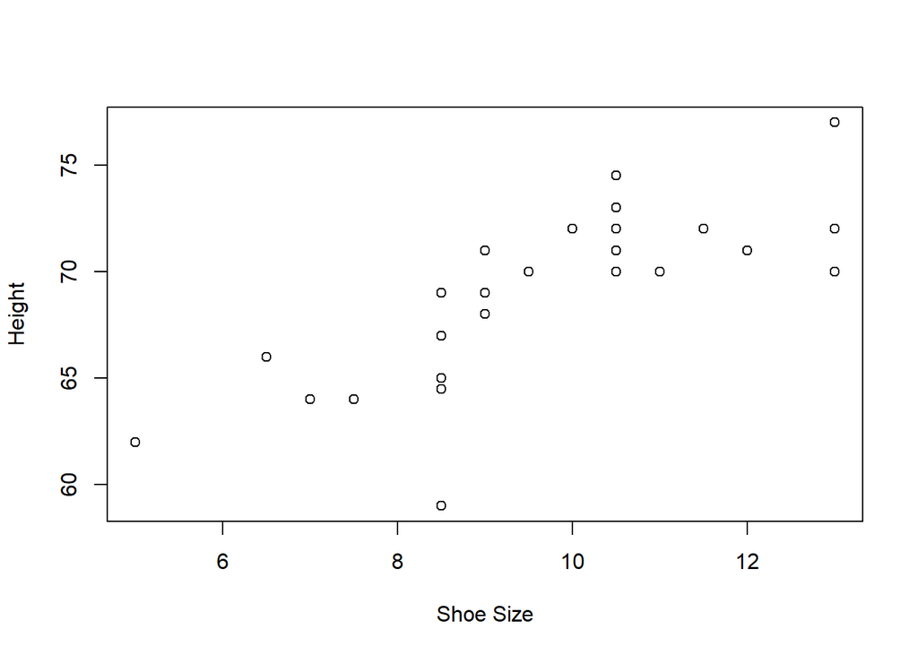

```r
plot(shoe_import$ShoeSize, shoe_import$Height,
     xlab = "Shoe Size", ylab = "Height")
```

Answer:

[1] 0.7766

-Yes, there is a strong positive relationship (correlation of about 0.78), so people with larger shoe sizes tend to be taller. Part of this comes from gender, since males are larger on both measures, but the relationship shows that body size and foot size grow together.

## Question #2

-A nominal variable is a categorical variable without an implied order. This means that it is impossible to say that ‘one is worth more than the other’. -Create factors for the gender.

```r
shoes <- read.csv("shoesize.csv")
shoes$Gender <- factor(shoes$Gender, levels = c("F", "M"))
str(shoes$Gender)
```

```
##  Factor w/ 2 levels "F","M": 1 1 1 1 2 1 1 1 2 1 ...
```

```r
table(shoes$Gender)
```

```
##
##  F  M
## 14 14
```

Answer:

Factor w/ 2 levels “F”,“M”: 1 1 1 1 2 1 1 1 2 1 …

F M 14 14

## Question #3

When R Markdown knits a document, it uses the folder containing the .Rmd file as the working directory — NOT whatever folder your R console happened to be in beforehand. Why do you think this design choice makes an .Rmd file’s imports more reliable and reproducible when shared with someone else?

Answer: -Using the .Rmd folder as the working directory means a relative path like read.csv(“shoesize.csv”) always looks next to the .Rmd file, so it works on any computer. Without this, the import would depend on whatever folder each person’s console happened to be in, and the knit would fail with “file not found.”

## Question #4

Run str(shoes) and note the type R assigned to the Gender column. Is it what you expected? Explain what could go wrong in later analysis if a column you expected to be numeric (like ShoeSize) was accidentally imported as text (character) instead — for example, because of a stray non-numeric value in the original file.

```r
str(shoes)
```

```
## 'data.frame':    28 obs. of  3 variables:
##  $ ShoeSize: num  6.5 9 8.5 8.5 10.5 7 9.5 9 13 7.5 ...
##  $ Height  : num  66 68 64.5 65 70 64 70 71 72 64 ...
##  $ Gender  : Factor w/ 2 levels "F","M": 1 1 1 1 2 1 1 1 2 1 ...
```

## Question #5

Why is it good practice to check BOTH head(shoes) and tail(shoes) after importing a file, instead of just head()? What kind of import problem would head() alone fail to catch?

```r
head(shoes)
```

```
##   ShoeSize Height Gender
## 1      6.5   66.0      F
## 2      9.0   68.0      F
## 3      8.5   64.5      F
## 4      8.5   65.0      F
## 5     10.5   70.0      M
## 6      7.0   64.0      F
```

```r
tail(shoes)
```

```
##    ShoeSize Height Gender
## 23     10.5     73      M
## 24      8.5     69      F
## 25     10.5     72      M
## 26     11.0     70      M
## 27      9.0     69      M
## 28     13.0     70      M
```

Answer: -head() shows only the top of the file, so it misses problems at the bottom, such as a stray footer row, a note or total line, blank rows, or a file that was cut off. tail() shows the end of the file, so checking both confirms the whole file was imported cleanly.

## Question #6

1. Compute for correlation TODO: Use cor(shoes$ShoeSize, shoes$Height) to compute the correlation between shoe size and height across ALL observations

```r
cor(shoes$ShoeSize, shoes$Height)
```

```
## [1] 0.7766089
```

Answer:

[1] 0.7766

2. TODO: Return all rows where ShoeSize is greater than or equal to 11, regardless of gender

```r
shoes[shoes$ShoeSize >= 11, ]
```

```
##    ShoeSize Height Gender
## 9      13.0     72      M
## 13     12.0     71      M
## 15     13.0     77      M
## 16     11.5     72      M
## 26     11.0     70      M
## 28     13.0     70      M
```

```r
# or: subset(shoes, ShoeSize >= 11)
```

Answer:

ShoeSize Height Gender 9 13.0 72.0 M 13 12.0 71.0 M 15 13.0 77.0 M 16 11.5 72.0 M 26 11.0 70.0 M 28 13.0 70.0 M

Question #7: -Compare the mean height and mean shoe size between the female and male subsets. Describe the pattern you see. -Does this dataset support the idea that shoe size and height are related WITHIN each gender group, or could gender itself be an important factor you’d need to account for separately when studying that relationship?

```r
females <- subset(shoes, Gender == "F")
males   <- subset(shoes, Gender == "M")

mean(females$ShoeSize); mean(females$Height)
```

```
## [1] 7.857143
```

```
## [1] 65.67857
```

```r
mean(males$ShoeSize);   mean(males$Height)
```

```
## [1] 10.96429
```

```
## [1] 71.46429
```

```r
cor(females$ShoeSize, females$Height)
```

```
## [1] 0.4923774
```

```r
cor(males$ShoeSize, males$Height)
```

```
## [1] 0.5188998
```

Answer:

[1] 7.857143 [1] 65.67857 [1] 10.96429 [1] 71.46429 [1] 0.49 [1] 0.52